# TP4_stochastic_gradient_and_co

**TP4: Stochastic gradient & co**  
**Ensimag 2A — Special grading lab**

**Student(s): GAMANGA Jérémy and LI Maxime**

```python
# Automatic reload of local libraries
%load_ext autoreload
%autoreload 2
%reload_ext autoreload
%matplotlib inline
```

> **I. Introduction**  
> **II. The optimization problem**  
> **III. Implementing the solvers**  
> GD (Gradient descent))  
> SGD (Stochastic Gradient Descent)  
> SAGA (Stochastic Average Gradient "Amélioré")  
> Comparison  
> **IV. Regularization**  
> **V. Further development**

In this lab, you will implement optimization algorithms that we've studied together and use them to fit a logistic regression classification model. Parts of this lab intersect TP2 and 3.

You will be implementing a simplified version of [`sklearn.linear_model.LogisticRegression`](https://scikit-learn.org/stable/modules/generated/sklearn.linear_model.LogisticRegression.html).

Part of the work has already been done for you (see the `\lib` folder), so you'll only have to implement the `##### TODO (i) #####` sections of the code. Whenever you complete such a section, we ask you to **copy it in this notebook**. We want you to **only send us a pdf or html export of this notebook** (so we won't be able to see your work if it's not in this notebook).

Report in groups of 1 to 2 students.

# I. Introduction

As in previous labs, we consider the [Student Performance](http://archive.ics.uci.edu/ml/datasets/Student+Performance) dataset. This dataset contains student demographic, social, school-related features, how many classes they've missed, etc.

The goal we give ourselves is to predict whether a student will pass (final grade > 12).

We denote $A \in \mathcal{M}_{n,d}(\mathbb{R})$ the feature matrix, containing $n$ samples with $d$ features, and $b \in \{-1,1\}^n$ the label vector where $-1$ encodes `fail` and $1$ encodes `pass`.

The data has already been preprocessed: You can check `\lib\datasets.py` if you're curious. The following loads the dataset:

```python
from lib.datasets import load_student_data

A_train, A_test, b_train, b_test = load_student_data('data/student-mat.csv', split=0.25)
```

As mentioned previously, you're going to implement a simplified version of [`sklearn.linear_model.LogisticRegression`](https://scikit-learn.org/stable/modules/generated/sklearn.linear_model.LogisticRegression.html). So let's first see the type of output it is supposed to give.

**Question:**

- Import [sklearn.linear_model.LogisticRegression](https://scikit-learn.org/stable/modules/generated/sklearn.linear_model.LogisticRegression.html) .
- Create an instance of sklearn's logistic regression classifiers with SAGA as its solver. (You may decrease the target accuracy to 0.001)
- Fit the classifier on the training data and compute the score of the fitted model on the test set.

```python
from sklearn.linear_model import LogisticRegression as lg

my_lg = lg(penalty='l2', tol=0.001, solver='saga') #pourquoi l1 + l2 fonctionne pas ?
my_lg.fit(A_train, b_train)

print("The score of the fitted model on the test set with l2 normalization is", my_lg.score(A_test, b_test))
```

```
The score of the fitted model on the test set with l2 normalization is 0.9292929292929293
```

# II. The optimization problem

Logistic regression consists in finding the parameter $x \in \mathbb{R}^d$ that best fits: $$ b_i = \begin{cases} \phantom{-}1 \ \textrm{ if }\ \langle a_{i}, x\rangle \ge 0 \\ -1 \ \textrm{ if }\ \langle a_{i}, x\rangle < 0 \end{cases} $$ for all the samples $i$ of the training set (where $a_i$ is the $i^{th}$ line of $A$ and $b_i$ the $i^{th}$ element of $b$). To measure this fit, logistic regression chooses the following loss:

$$ \textrm{LogisticLoss}(b_i, \left\langle a_{i}, x\right\rangle ) = \log \left(1+\exp \left(-b_{i}\left\langle a_{i}, x\right\rangle\right)\right) $$

The corresponding optimization problem we will consider is the following:

Minimization of the empirical risk $f$ of the $L_2$-regularized logistic regression model, on the dataset $(A_{\textrm{train}},b_{\textrm{train}})$: $$ \begin{aligned} \textrm{min}_{x\in \mathbb{R}^d} \ f(x) \ &= \ \textrm{min}_{x\in \mathbb{R}^d} \ \frac{1}{n_{\textrm{train}}} \sum_{i=1}^{n_{\textrm{train}}} f_i(x) \\ &= \ \textrm{min}_{x\in \mathbb{R}^d}\frac{1}{n_{\textrm{train}}} \sum_{i=1}^{n_{\textrm{train}}} \textrm{LogisticLoss}(b_i, \left\langle a_{i}, x\right\rangle ) + \frac{l_2}{2}\|x\|^{2}_2, \end{aligned} $$ where $l_2 \ge 0$ is the regularization parameter.

To simplify the notation, we'll stop indexing $A$, $b$ and $n$ with "$\textrm{train}$" in the following.

Note that the functions $f_i$s and $f$ are $C^1$ with $L$-Lischitz gradient, with $L \le \frac{\max_i\|a_i\|^2_2}{4} + l_2$ and we can therefore use the following value in our implementation:

```
L = 0.25 * max(np.linalg.norm(A,2,axis=1))**2 + self.l2
```

# III. Implementing the solvers

To implement gradient methods, we need an oracle that will compute both batch gradients $\nabla f$ and partial gradients $\nabla f_i$.

**Question:** In the code below, $\nabla f$ has already been implemented.

- Complete **TODO (1)** below.
- Add your code to **\lib\linear_model.py**.

```
def grad(x, i=None):
    '''
    Gradient of the objective function at x.
    If no i is given, grad should return the batch gradient.
    Otherwise, it should return the partial gradient associated the the datapoint (A[i], b[i]).
    '''

    if i is None: # return batch gradient
        output1 = -b/(1 + np.exp(b*np.dot(A, x)))
        output = sum(np.diag(output1))/n @ A
        output += self.l2*x
    else: # return partial gradient associated the datapoint (A[i], b[i])
        output = -b/(1 + np.exp(b[i]*np.dot(A[i], x))) + self.l2*x
        #pass
    return output
```

# GD (Gradient descent)

At iteration k of the GD algorithm, the following update is executed:

$$ x_{k+1} \leftarrow x_{k} - \gamma\nabla f(x_k) $$

**Question:**

- What stepsize $\gamma$ ensures the convergence of this algorithm ?
- Complete **TODO (2)** and **TODO (3)**
- Add your code to **\lib\solvers.py**.

> **Answer:** Un pas de $\gamma \leq \frac{2}{L}$ garantie la convergence de l'algorithme.

```
def GD(x0, grad, max_iter, n, L, mu):
    '''
    Parameters
    ----------
    x0: array, shape (nb_features,)
        Initialisation of the solver
    grad: function
        Gradient of the objective function
    max_iter: int
        Number of iterations (i.e. number of descent steps). Note that for GD,
        one iteration is one epoch i.e, one pass through the data, while for SGD, SAG and SAGA,
        one iteration uses only one data point.
    n: int
        Dataset size
    L: float
        Smoothness constant of the objective function
    mu: float
        Strong convexity constant of the objective function

    Returns
    -------
    x: array, shape (nb_features,)
        final iterate of the solver
    x_tab: array, shape (nb_features, max_iter)
        table of all the iterates
    '''
    if L == 0:
        return None, None

    stepsize  = 2/L ######## TODO (2) ########
    x         = x0
    x_tab     = np.copy(x)

    for k in range(max_iter):
        x     = x - stepsize* grad(x) ######## TODO (3): Implement a single step ########
        x_tab = np.vstack((x_tab, x))

    return x, x_tab
```

**Question:** Run the code below to test your code.

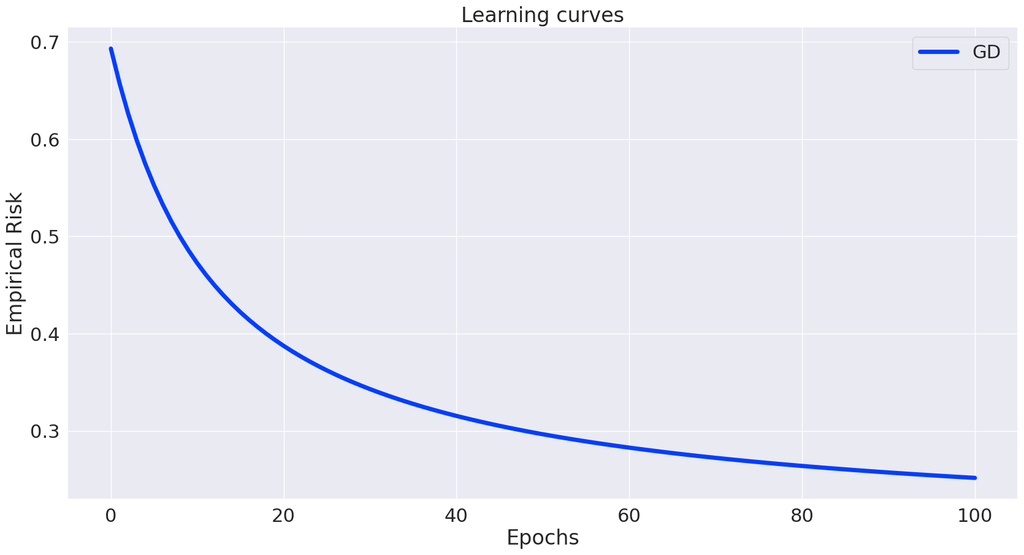

```
The score of the fitted model on the test set is 0.8787878787878788
```

```python
from lib.linear_model import LogisticRegression
from lib.visuals import learning_curve

clf_gd = LogisticRegression(solver='gd', l2=0.01, max_iter=100)
clf_gd.fit(A_train, b_train)

learning_curve(GD=clf_gd)
print("The score of the fitted model on the test set is", clf_gd.score(A_test, b_test))
```

# SGD (Stochastic Gradient Descent)

At iteration k of the SGD algorithm, the following update is executed:

$$ \begin{cases} i \textrm{ chosen randomly in } \{1...n\}\\ x_{k+1} \leftarrow x_{k} - \gamma_k \nabla f_i(x_k) \\ \end{cases} $$

**Question:**

- What stepsize $\gamma_k$ ensures the convergence of this algorithm and under what assumptions?
- Complete **TODO (4)**
- Add your code to **\lib\solvers.py**.

Un pas constant égale à $\gamma_k = \gamma = \frac{\gamma_0}{(+\frac{\kappa}{\kappa_0})^{\alpha}}$. Avec $\alpha = 0,5$ ou $0,6$.

Pour le TP on prendre $\kappa_0 =1$ et $\gamma_0 = \frac{2}{L}$

```
import random as rd
def SGD(x0, grad, max_iter, n, L, mu):
    ######## TODO (4) ########
    x_tab = x0
    gamma0 = 2/L
    kappa = mu/L
    stepsize = gamma0/(1+kappa)**0.5
    for k in range(max_iter):
        ######## TODO (4) ########
        i = rd.randint(0,n-1)


        x = x - stepsize * grad(x,i)
        if k%n == 0: # each completed epoch
            x_tab = np.vstack((x_tab, x))

    return x, x_tab
```

**Question:** Run the code below to test your code.

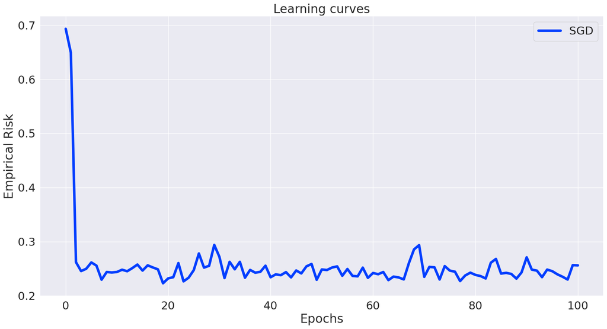

```python
clf_sgd = LogisticRegression(solver='sgd', l2=0.01, max_iter=100*len(b_train))
clf_sgd.fit(A_train, b_train)

learning_curve(SGD=clf_sgd)
```

# SAGA (Stochastic Average Gradient "Amélioré")

SAGA starts by computing a single batch gradient, then at iteration k, the following update is executed:

$$ \begin{cases} i \textrm{ chosen randomly in } \{1...n\}\\ x_{k+1} \leftarrow x_{k} - \gamma_k\big(\nabla f_i(x_k) - \alpha_i + \bar{\alpha}\big) \\ \alpha_i \leftarrow \nabla f_i(x) \end{cases} $$

where $(\alpha_j)_{j=1}^n$ are gradients evaluated at previous iterates and $\bar{\alpha}=\frac{1}{n}\sum^n_{j=1}\alpha_j$.

**Question:**

- What stepsize $\gamma_k$ ensures the convergence of this algorithm and under what assumptions?
- Complete **TODO (5)**
- Add your code to **\lib\solvers.py**.

En supposant que la fonction objective soit $\mu$-fortement convexe et $L$-fortement différentiable. On peut prendre $\gamma = \frac{1}{2(\mu n+L)}$

```
def SAGA(x0, grad, max_iter, n, L, mu):
    x_tab = x0
    x=x0
    alpha = [grad(x0, i) for i in range(0,n)]
    stepsize = 1/2/(mu*n+L)
    for k in range(max_iter):
        ######## TODO (5) ########
        i = rd.randint(0,n-1)
        alphab = sum(alpha)/n
        xk = np.copy(x)
        x = x - stepsize*(grad(x,i)-alpha[i]+alphab)
        alpha[i] = grad(xk,i)
        if k%n == 0: # each completed epoch
            x_tab = np.vstack((x_tab, x))

    return x, x_tab
```

**Question:** Run the code below to test your code.

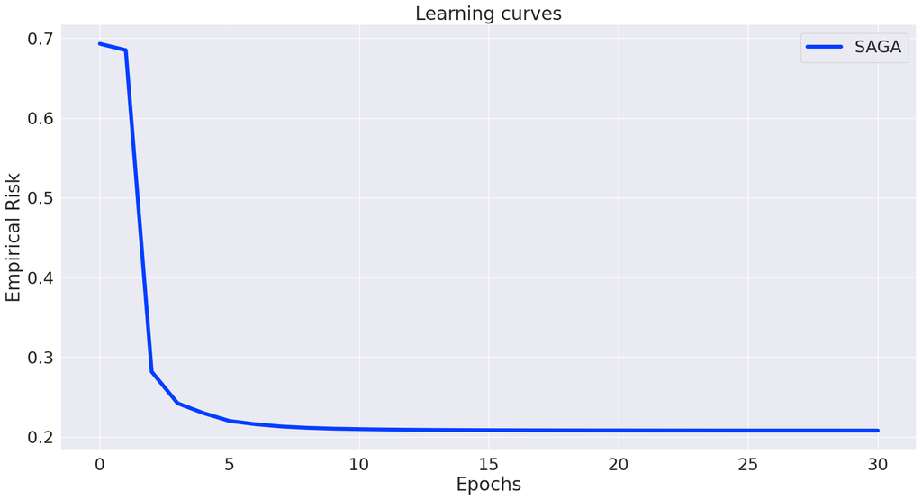

```python
clf_saga = LogisticRegression(solver='saga', l2=0.01, max_iter=30*len(b_train))
clf_saga.fit(A_train, b_train)

learning_curve(SAGA=clf_saga)
```

# Comparison

**Question:** Run the code below to compare all the methods you've implemented.

```python
epochs = 50
n = len(b_train)

clf_gd   = LogisticRegression(solver='gd', l2=0.01, max_iter=epochs)
clf_sgd  = LogisticRegression(solver='sgd', l2=0.01, max_iter=epochs*n)
clf_saga = LogisticRegression(solver='saga', l2=0.01, max_iter=epochs*n)

clf_gd.fit(A_train, b_train)
clf_sgd.fit(A_train, b_train)
clf_saga.fit(A_train, b_train)
```

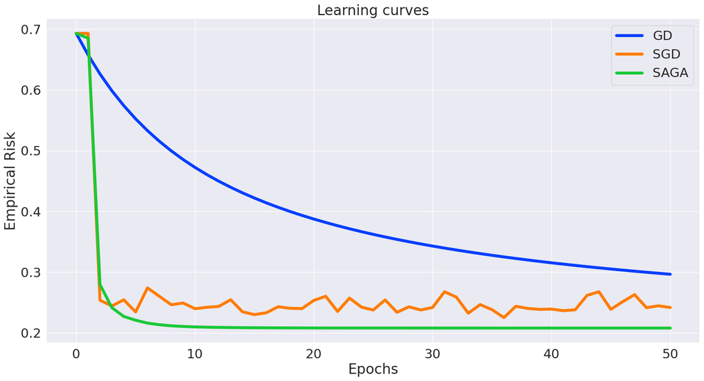

```
gd:	Accuracy on training set: 90.5%
	Accuracy on testing set:  87.9%
sgd:	Accuracy on training set: 92.6%
	Accuracy on testing set:  91.9%
saga:	Accuracy on training set: 93.9%
	Accuracy on testing set:  92.9%
```

```python
learning_curve(GD=clf_gd, SGD=clf_sgd, SAGA=clf_saga)

for clf, name in zip([clf_gd, clf_sgd, clf_saga], ['gd', 'sgd', 'saga']):
    print(name + ':' \
          + "\tAccuracy on training set: {0:0.1f}%".format(100*clf.score(A_train, b_train)))
    print("\tAccuracy on testing set:  {0:0.1f}%".format(100*clf.score(A_test, b_test)))
```

Tout d'abord on remarque que numériquement les trois algorithmes ont un score de plus de 85% sur les données de tests, ce qui en font de bon solveur.

Ensuite on remarque que l'algorithme GD est plus lent que les algorithmes SGD et SAGA dans la minimisation de l'erreur empirique (notre fonction objective). En effet, pour un même nombre de passage sur les données (Epochs), le GD n'est pas aussi efficace de le SDG et le SAGA. A 10 epochs on est à un risque empirique de moins de 0.25 pour le SAGA et le SAG, alors que le GD vient à peine de passer sous la bar des 0.5.

ON constate que le SAGA est meilleur que le SGD, non seulement il atteint un seuil plus bas mais il est aussi plus stable que. On remarque des flutuations du risque empirique pour l'algorithme SGD. Ce qui traduit bien le problème de variance qui apparait lorsqu'on choisit au hasard le gradient à utiliser dans à chaque itération pour l'algorithme SGD. Problème que résoud le SAGA en prenant une moyenne de gradient, afin de diminuer la variance.

# IV. Regularization

**Question:**

- Rewrite the empirical risk minimization objective with both $L_1$ and $L_2$ regularization (with coefficients $l_1$ and $l_2$).
- Is this objective $\mu$-strongly convex, $L$-smooth, differentiable?
- Complete the **TODO (6)** to account for the new term in the objective.
- Add your code to **lib/linear_model.py**.

> **Answer:**

```
self._empirical_risk = lambda x: sum(self._logistic_loss(A, b, x))/n \
                                 + self.l2/2.0 * np.linalg.norm(x,2) \
                                 + self.l1*np.linalg.norm(x,1) ######## TODO (6) ########
```

The minimization algorithms we've implemented have a slow rate of convergence for this new objective function. We will therefore use *proximal* variations of these algorithms.

**Question:** Using the $\textrm{prox}_{l_1 \|\cdot\|_1}$ operator, write down the $k^{th}$ step of proximal GD, proximal SGD, and proximal SAGA.

> **Answer:**

Pour le GD : $$x_{k+1} \leftarrow \textrm{prox}_{l_1 \|\cdot\|_1}(x_{k} - \gamma\nabla f(x_k))$$

Pour le SGD : $$ \begin{cases} i \textrm{ chosen randomly in } \{1...n\}\\ x_{k+1} \leftarrow \textrm{prox}_{l_1 \|\cdot\|_1}(x_{k} - \gamma_k \nabla f_i(x_k)) \\ \end{cases} $$

Pour le SAGA:

$$ \begin{cases} i \textrm{ chosen randomly in } \{1...n\}\\ x_{k+1} \leftarrow \textrm{prox}_{l_1 \|\cdot\|_1}(x_{k} - \gamma_k\big(\nabla f_i(x_k) - \alpha_i + \bar{\alpha}\big)) \\ \alpha_i \leftarrow \nabla f_i(x) \end{cases} $$

**Question:**

- Give a closed-form expression of $\textrm{prox}_{l_1 \|\cdot\|_1}$
- Complete **TODO (7)** (note that you can access the $l_1$ coefficient using **self.l1**).
- Add your code to **\lib\linear_model.py**.

> **Answer:**

$$\forall i \in [|1,d|]$$$$ (\textrm{prox}_{l_1 \|\cdot\|_1})_{i} \begin{cases} x_i - l_1 \ \ si \ \ x_1 \gt l_1 \\ x_i + l_1 \ \ si \ \ x_1 \lt l_1 \\ 0\ \ sinon \end{cases} $$

```
def prox(x,stepsize):
    ######## TODO (7) ########
    p = np.zeros(len(x))
    gamma = stepsize * self.l1

    for i in range(len(x)):
        if x[i] > gamma:
            p[i] = x[i] - gamma
        elif x[i] < -gamma:
            p[i] = x[i] + gamma
        else:
            p[i] = 0

    return p
```

**Question:**

- Add **prox** to the attributes of the solvers (both in the call to **self.solver** in **/lib/linear_model.py** and in **/lib/solvers.py**) as follows:  
  solver(x0, grad, **prox**, self.max_iter, n, L, mu)
- Add a proximal step to all the algorithms in **/lib/solvers.py**.
- Paste one of these algorithms in the cell bellow.

```
def GD(x0, grad, prox, max_iter, n, L, mu):
    if L == 0:
        return None, None

    stepsize  = 2/L
    x         = x0
    x_tab     = np.copy(x)

    for k in range(max_iter):
        x     = prox(x - stepsize* grad(x), stepsize)
        x_tab = np.vstack((x_tab, x))

    return x, x_tab

def SGD(x0, grad, prox, max_iter, n, L, mu):

    stepsize  = 2/L*(1/(1+mu/L)**(0.5))
    x         = x0
    x_tab     = np.copy(x)

    for k in range(max_iter):

        i = rd.randint(0, n-1)
        x = prox(x - stepsize*grad(x, i), stepsize)
        if k%n == 0: # each completed epoch
            x_tab = np.vstack((x_tab, x))

    return x, x_tab

def SAGA(x0, grad, prox, max_iter, n, L, mu):
    x_tab = x0
    x=x0
    alpha = [grad(x0, i) for i in range(0,n)]
    stepsize = 1/2/(mu*n+L)

    for k in range(max_iter):

        i = rd.randint(0,n-1)
        alphab = sum(alpha)/n
        xk = np.copy(x)
        x = prox(x - stepsize*(grad(x,i)-alpha[i]+alphab), stepsize)
        alpha[i] = grad(xk,i)
        if k%n == 0:
            x_tab = np.vstack((x_tab, x))

    return x, x_tab
```

**Question:** If your proximal gradient is correctly implemented, the following cell plots the support of the solution for various values of $l_1$.

- Interpret the plot and explain what can $L_1$ regularization be used for.

> **Answer:**

On voit qu'un $l_1$ bien choisit permet d'avoir une solution $x$ du problème d'optimisation avec un support réduit. Elle permet d'avoir $x$ parcimonieux et nous permet d'avoir un paramètre pour notre modèle avec uniquement les composantes les plus importantes pour la prédiction.

Cette régularisation permet de réduire la taille de notre modèle au "strict nécessaire".

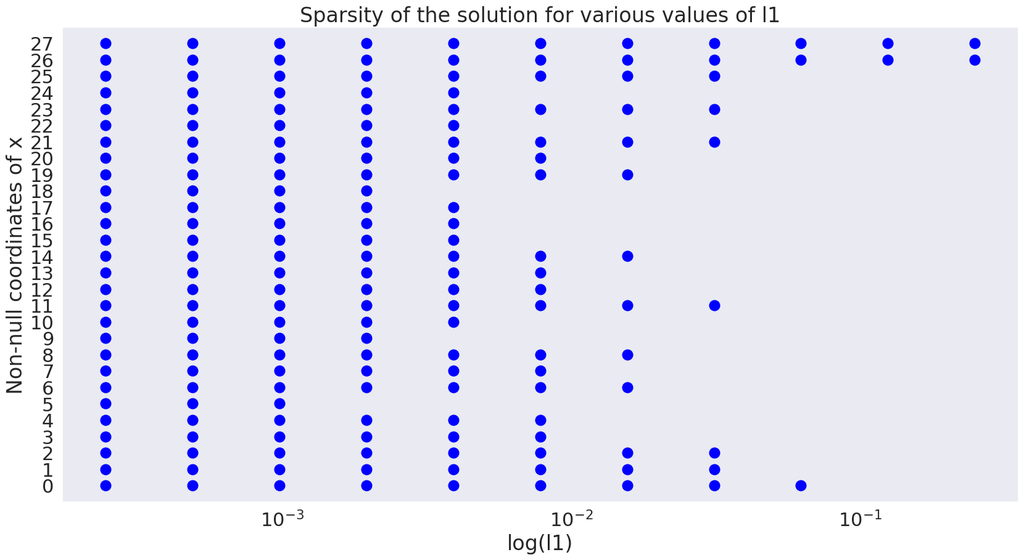

```python
from lib.visuals import l1_regularization_plot

clf = lambda l1: LogisticRegression(solver='gd', l1=l1, l2=0.1, max_iter=1000)

l1_regularization_plot(clf, A_train, b_train)
```

**Question:** The following cell will plot the value of the coordinates of the solution for various values of $l_2$.

- Interpret the plot and explain what can $L_2$ regularization be used for.

> **Answer:**

On peut voir que plus la valeur de l2 est grande plus la norme de chaque coefficient de x diminue, celà sans distinction du coefficient. Dans la pratique cela conduit à un handicap pour l'algorithme qui va réduire l'overfitting.

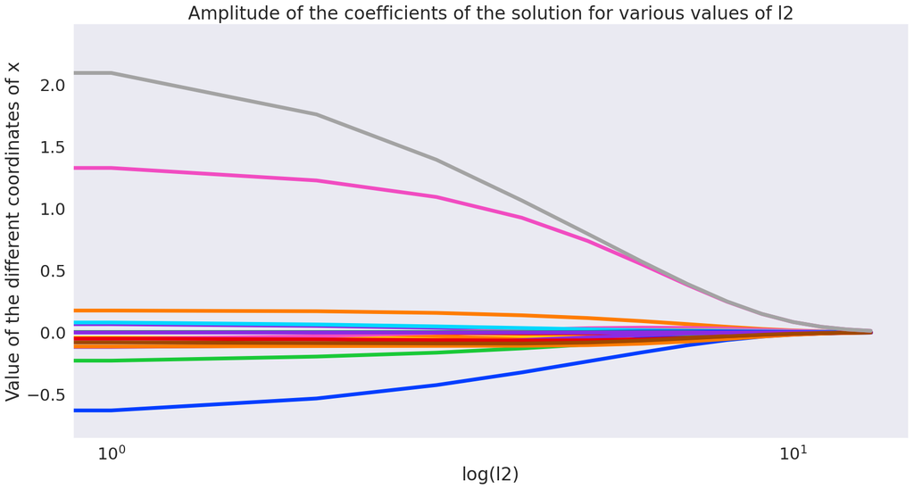

```python
from lib.visuals import l2_regularization_plot

clf = lambda l2: LogisticRegression(solver='gd', l1=0.01, l2=l2, max_iter=1000)

l2_regularization_plot(clf, A_train, b_train)
```

# V. Further development

We expect that you go beyond these questions and that you develop certain aspects, depending on your personal interests and skills, for instance:

- Implementations and numerical tests (further developments, more experiments, etc.)
- Applications in learning or statistics (interpretation of some results, other models, other datasets, etc.)
- Theoretical or mathematical questions (convergence proofs, convergence rates, advanced versions of an algorithm, theoretical analysis of special cases, etc.)